# Step 6: Initial Model Setup and Steady State

## 4.2 Initial Size Spectrum

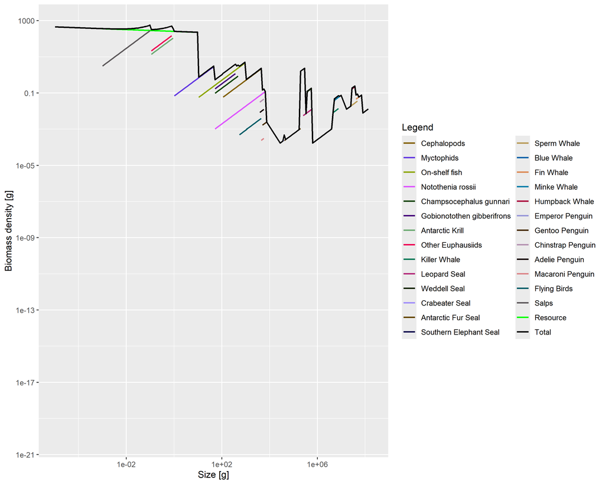

Figure 2: Initial size spectrum by species

Figure 2 shows the abundance-size distribution for all species in the initial model state. The plot uses Sheldon spectrum notation (abundance × weight² vs weight) which produces flat spectra under equilibrium conditions.

**Key features**:

- **Power = 2**: Sheldon spectrum normalization
- **Total line**: Community-level size spectrum (black line)
- **Species lines**: Individual species contributions (colored)
- **Resource spectrum**: Background plankton (typically leftmost portion)

## 4.3 Validation Tests

### 4.3.1 Test Simulation

A short 1-year test simulation was performed to verify:

- ✓ No numerical instabilities
- ✓ No negative abundances
- ✓ Reasonable feeding rates
- ✓ Energy conservation
- ✓ Mass balance

**Result**: Success (documented in model summary output)

# 5 Steady State Analysis

## 5.1 Approach

Finding a true steady state in multi-species size-spectrum models is challenging due to:

1. **Complex dynamics**: 26 interacting species with different life histories
2. **Size structure**: Each species has multiple size classes (cohorts)
3. **Predator-prey cycles**: Natural oscillations in some interactions
4. **Stochasticity**: Inherent variability in ecological dynamics

## 5.2 Simulation Results

### 5.2.1 Biomass Time Series

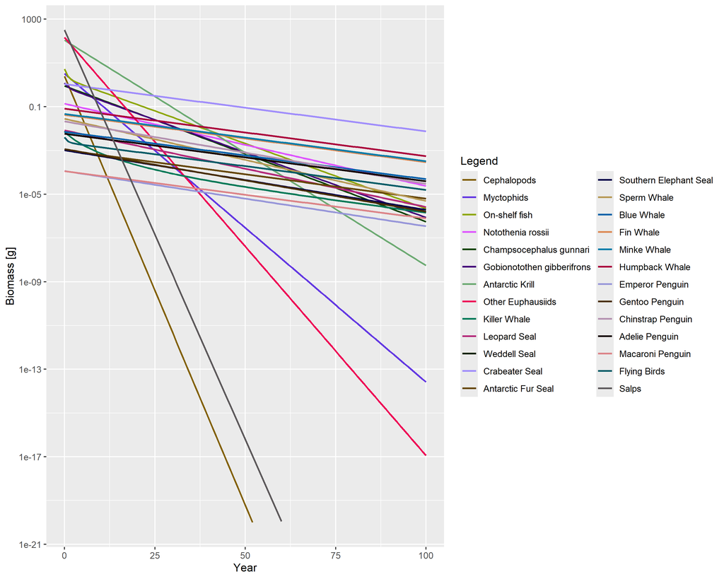

Figure 3: Biomass trajectories during steady state run

### 5.2.2 Stability Assessment

Coefficient of variation and overall assessment are calculated by the setup script and documented in the model summary output.

**NoteNatural Variability**

Multi-species models often exhibit some variability even at “steady state” due to:

- Predator-prey cycles (especially krill-predator interactions)
- Cohort effects (recruitment pulses)
- Size-dependent interactions
- Reproductive stochasticity

A model with CV < 0.1-0.2 is generally considered acceptably stable for calibration purposes.

## 5.3 Steady State Biomass

### 5.3.1 Comparison with EwE

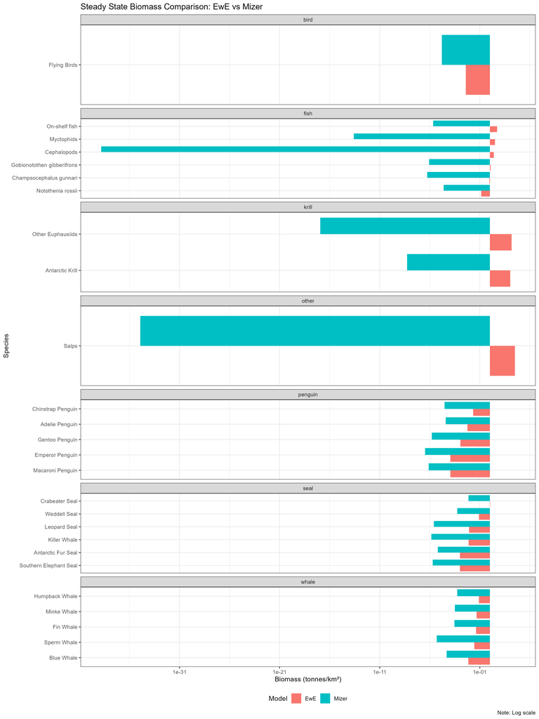

Figure 4: Steady state biomass compared to EwE

Figure 4 compares biomass distributions after equilibration with EwE to assess how the model settles relative to the reference state. Detailed biomass change analysis is documented in the model summary output.

## 5.4 Steady State Size Spectrum

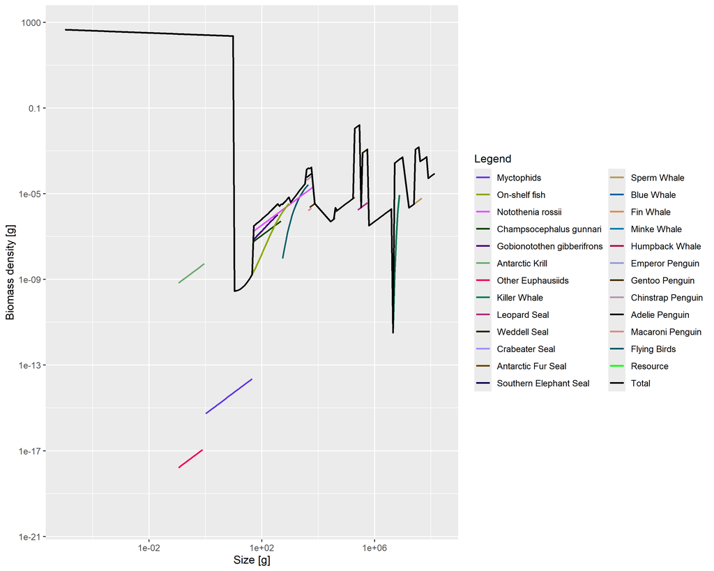

Figure 5: Steady state size spectrum

# 6 Model Diagnostics

## 6.1 Growth Curves

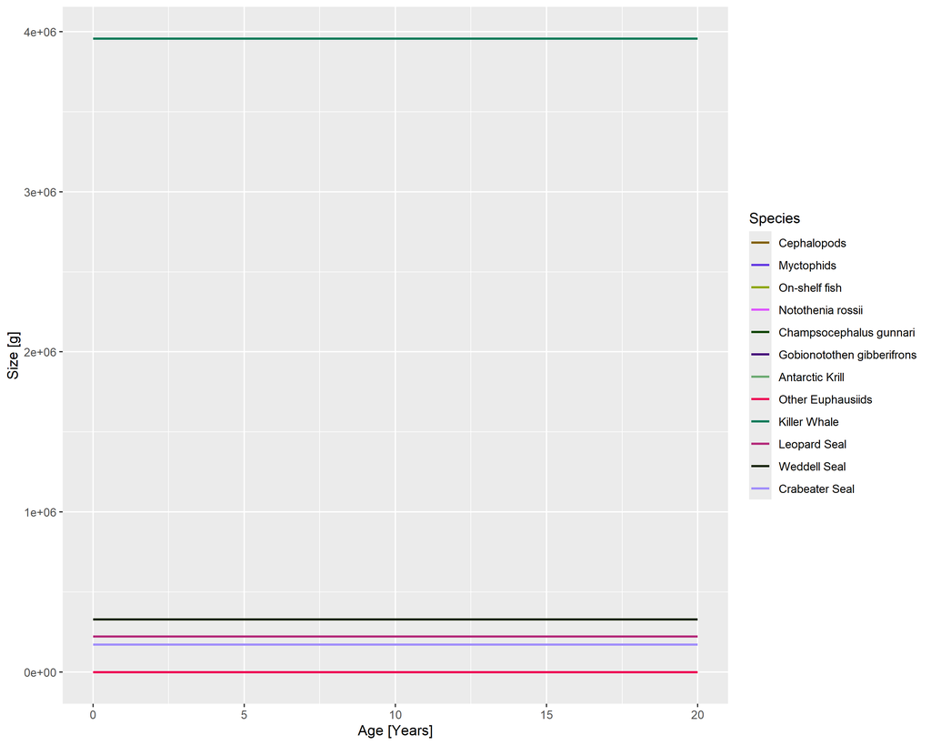

Figure 6: Growth curves by species

**Validation**: Compare with known growth rates from literature for key species (Antarctic Krill, icefish, etc.)

## 6.2 Feeding Level

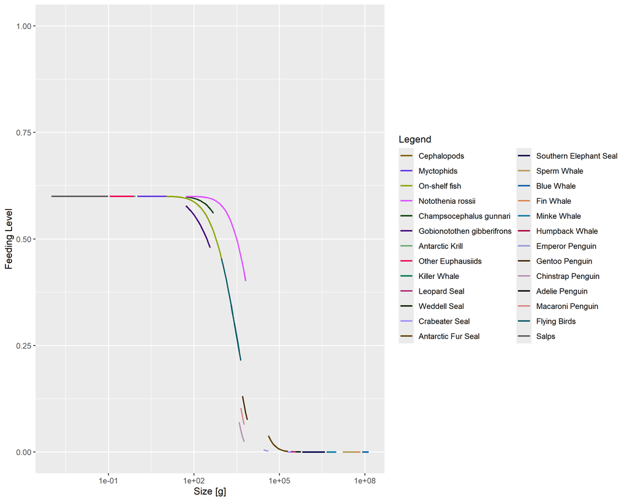

Figure 7: Feeding level by species and size

Figure 7 shows feeding level ($f$), which represents the ratio of realized consumption to maximum possible consumption:

$$f = \frac{\text{Actual intake}}{\text{Maximum intake}}$$

**Interpretation**:

- **f ≈ 1**: Satiated, food abundant
- **f ≈ 0.5**: Moderate food availability
- **f < 0.3**: Food-limited, may indicate issues
- **f > 0.95**: Potentially over-feeding

**Expected patterns**:

- Small individuals (juveniles): Higher f (abundant small prey)
- Large individuals: Lower f (fewer suitable prey)
- Specialists: Variable f (dependent on specific prey)
- Generalists: Stable f (can switch prey)